## Contents

Summary Data processing Initial Analysis Further Analysis DP00534 DP01057 DP01058 DP00916 DP00469 Conclusions

# Evaluation of DISOPRED3 for protein disorder prediction

Authors:  
Shawn Queen, shawn.queen25@uga.edu  
Liangjiao Xue, liangjiao.xue@gmail.com  
Jake Reeves, jake.reeves2013@gmail.com  
Copy Right:  
Tsai Lab UGA, cjtsai@uga.edu  
Liangjiao Xue, liangjiao.xue@gmail.com

## Summary

The purpose of this code is to graphically represent the accuracy and sensitivity of the protein disorder prediction software DISOPRED 3 relative to a curated data set retrieved from DisProt.

*Inputs:*  
1) Raw .diso file format output from DISOPRED3, placed in a folder named “disopred”  
2) Manually created vertical matrix of binary data where 1 = disordered and 0 = ordered, placed in a folder named “disprot”

*Outputs:*  
1) An R dataframe containing protein sequence and disorder information  
2) A graph that plots the continuous variable of DISOPRED3’s predicted disorder versus the binary discrete variable of DisProt’s observed disorder

*Note:* *The initial analysis section is not necessary for further use of the program and can be removed if necessary.*

## Data processing

To do this, protein entries from *Arabidopsis thaliana* were retrieved from DisProt, a manually-curated database of experimental protein disorder data, and the amino acid sequences used as input for DISOPRED3. The output from DISOPRED3 is used as input for the graph, as well as manually-created files from DisProt entry data.

```r
# Set working directory
setwd("../ProteinDisorder/data/")

# Read in files for each protein
# DP00534
tmp <- read.table(file = "disopred/DP00534.diso")
tmp2 <- read.table(file = "disprot/DP00534.txt")
DP00534 <- cbind(tmp, tmp2)
names(DP00534) <- c("Number","AA","Dis_Bin","Dis_Score","Exp_Bin")

# DP01057
tmp <- read.table(file = "disopred/DP01057.diso")
tmp2 <- read.table(file = "disprot/DP01057.txt")
DP01057 <- cbind(tmp, tmp2)
names(DP01057) <- c("Number","AA","Dis_Bin","Dis_Score","Exp_Bin")


# DP01058
tmp <- read.table(file = "disopred/DP01058.diso")
tmp2 <- read.table(file = "disprot/DP01058.txt")
DP01058 <- cbind(tmp, tmp2)
names(DP01058) <- c("Number","AA","Dis_Bin","Dis_Score","Exp_Bin")

# DP00916
tmp <- read.table(file = "disopred/DP00916.diso")
tmp2 <- read.table(file = "disprot/DP00916.txt")
DP00916 <- cbind(tmp, tmp2)
names(DP00916) <- c("Number","AA","Dis_Bin","Dis_Score","Exp_Bin")

# DP00469
tmp <- read.table(file = "disopred/DP00469.diso")
tmp2 <- read.table(file = "disprot/DP00469.txt")
DP00469 <- cbind(tmp, tmp2)
names(DP00469) <- c("Number","AA","Dis_Bin","Dis_Score","Exp_Bin")
rm(tmp)
rm(tmp2)
```

## Initial analysis

Interestingly, five proteins were predicted by DISOPRED to have 100% disorder, with no folding activity. *Checking these five proteins against the curated data in DisProt reveals that DISOPRED correctly predicted their disorder with perfect accuracy.* There was no clear correlation between length and disorder in this data set. This could be because of the relatively small size of the data set, or because of the fact that DisProt is a manually-curated database of proteins that were studied because of their unique disorder.

```r
disordertable <- read.csv("data/disorder_table.csv", header = TRUE)
names(disordertable) <- c("Entry","Length","Residues(DISOPRED)","Residues(DisProt)","Percent(DISOPRED)","Percent(DisProt)","Error")
disordertable
```

```
##      Entry Length Residues(DISOPRED) Residues(DisProt) Percent(DISOPRED) Percent(DisProt)       Error
## 1  DP00534    131                 60               131        45.8015267       100.000000  54.1984733
## 2  DP01057    139                117                99        84.1726619        71.223022 -12.9496403
## 3  DP01058    141                 88                99        62.4113475        70.212766   7.8014184
## 4  DP00916    146                 15                17        10.2739726        11.643836   1.3698630
## 5  DP00469    168                116                77        69.0476190        45.833333 -23.2142857
## 6  DP00667    185                185               185       100.0000000       100.000000   0.0000000
## 7  DP00689    186                186               186       100.0000000       100.000000   0.0000000
## 8  DP00658    193                193               193       100.0000000       100.000000   0.0000000
## 9  DP00606    260                260               260       100.0000000       100.000000   0.0000000
## 10 DP00657    265                265               265       100.0000000       100.000000   0.0000000
## 11 DP00880    300                  1                 8         0.3333333         2.666667   2.3333333
## 12 DP00723    345                 16                13         4.6376812         3.768116  -0.8695652
## 13 DP00724    533                140               103        26.2664165        19.324578  -6.9418387
## 14 DP01085    640                104                88        16.2500000        13.750000  -2.5000000
## 15 DP00474    681                185               200        27.1659324        29.368576   2.2026432
## 16 DP00654    725                 24                33         3.3103448         4.551724   1.2413793
## 17 DP00610   1206                858               456        71.1442786        37.810945 -33.3333333
## 18 DP00609   1503               1158              1360        77.0459082        90.485695  13.4397871
```

*Table 1, DISOPRED results for each DisProt entry. DISOPRED error was found by subjecting the percentage disorder predicted by DISOPRED from the percentage disorder found in DisProt.*

## Further Analysis

DISOPRED3’s output data is a space-delimited table with a header (that is automatically excluded by R’s read.table function). Column 1 is the residue number, column 2 is the amino acid abbreviation for that residue, column 3 is a binary indicator of a residue’s disorder, and column 4 is the disorder score for that residue. This data can be read as binary (column 3) or “continuous” data (column 4), and for this project we are reading it as “continuous.” The data is plotted as a simple line plot with residue on the x axis, disorder level on the y axis, and amino acid abbreviation labeling the x axis (*work-in-progress*). A single red line denotes the cutoff between what is considered an ordered or disordered residue. *Work in progress: Additional data from Disprot database will be overlaid onto the graph to indicate regions that were experimentally validated as disordered or ordered. Currently this data is being manually added in R rather than integrated with a script or program.*

Shown below is the graph for protein DP00534 (UniProt entry here)[http://www.uniprot.org/uniprot/Q9LZP9], which DISOPRED3 scored the worst on in terms of accuracy out of the DisProt group. *DisProt lists this protein as entirely disordered, yet DISOPRED only calculated roughly 50% disorder.* BLASTP search reveals that DP00534 appears to be well-conserved across the plant kingdom despite its short length. This is not surprising, given that it is “Calvin cycle protein CP12-2, chloroplastic”.

## DP00534

```
## geom_path: Each group consists of only one observation. Do you need to adjust the group aesthetic?
```

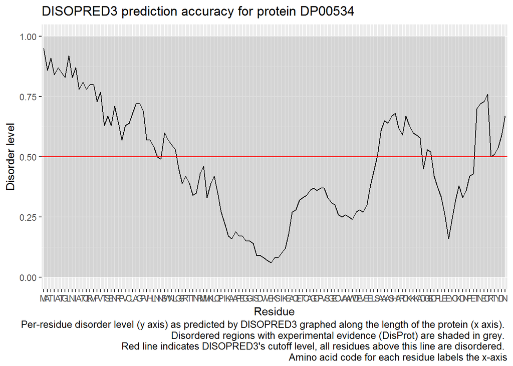

```r
ggplot() + geom_line(aes(x=factor(DP00534$Number), y=DP00534$Exp_Bin)) +
           geom_area(aes(x=DP00534$Number, y=DP00534$Exp_Bin), fill="grey", alpha=0.5) +
           geom_line(aes(x=DP00534$Number, y=DP00534$Dis_Score)) +
           geom_hline(yintercept=.5, color="red") +
           labs(x="Residue",y="Disorder level", title = "DISOPRED3 prediction accuracy for protein DP00534", caption="Per-residue disorder level (y axis) as predicted by DISOPRED3 graphed along the length of the protein (x axis). \nDisordered regions with experimental evidence (DisProt) are shaded in grey. \nRed line indicates DISOPRED3's cutoff level, all residues above this line are disordered. \nAmino acid code for each residue labels the x-axis") + scale_x_discrete(labels=DP00534$AA)
```

## DP01057

```
## geom_path: Each group consists of only one observation. Do you need to adjust the group aesthetic?
```

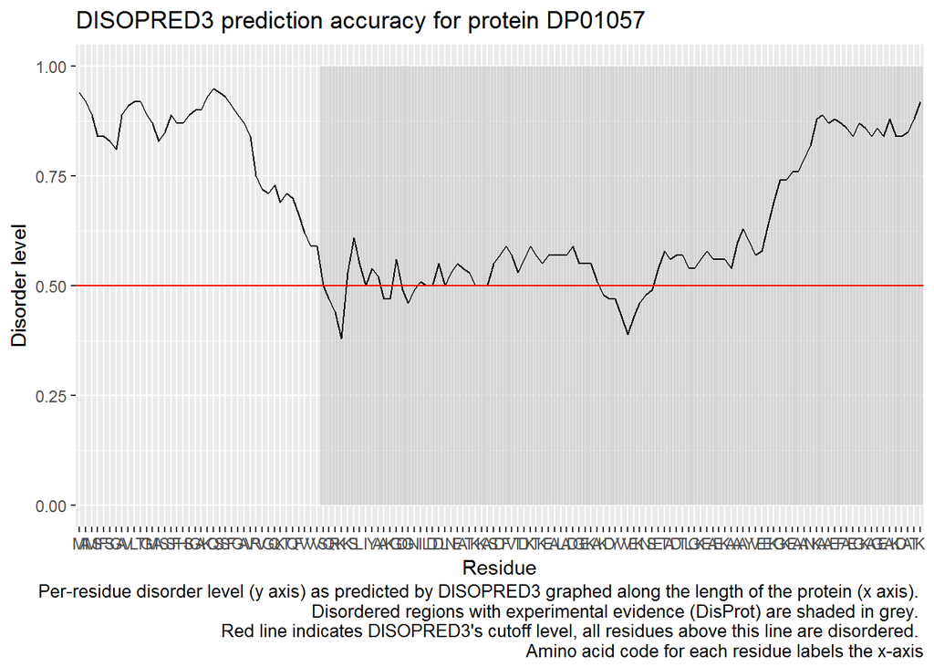

```r
ggplot() + geom_line(aes(x=factor(DP01057$Number), y=DP01057$Exp_Bin)) +
           geom_col(aes(x=DP01057$Number, y=DP01057$Exp_Bin), fill="grey", alpha=0.5) +
           geom_line(aes(x=DP01057$Number, y=DP01057$Dis_Score)) +
           geom_hline(yintercept=.5, color="red") +
           labs(x="Residue",y="Disorder level", title = "DISOPRED3 prediction accuracy for protein DP01057", caption="Per-residue disorder level (y axis) as predicted by DISOPRED3 graphed along the length of the protein (x axis). \nDisordered regions with experimental evidence (DisProt) are shaded in grey. \nRed line indicates DISOPRED3's cutoff level, all residues above this line are disordered. \nAmino acid code for each residue labels the x-axis") + scale_x_discrete(labels=DP01057$AA)
```

## DP01058

```
## geom_path: Each group consists of only one observation. Do you need to adjust the group aesthetic?
```

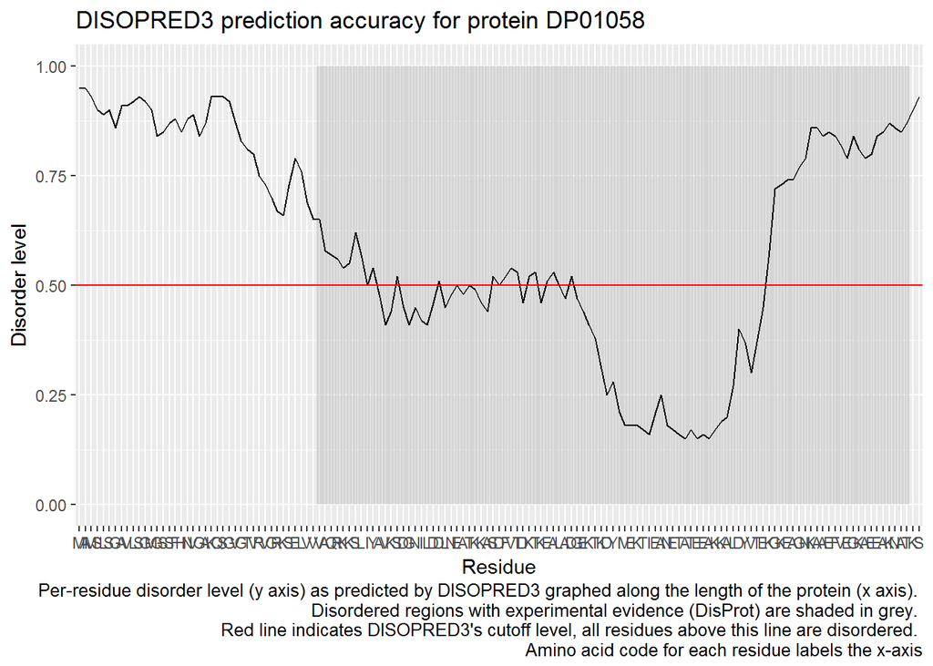

```r
ggplot() + geom_line(aes(x=factor(DP01058$Number), y=DP01058$Exp_Bin)) +
           geom_col(aes(x=DP01058$Number, y=DP01058$Exp_Bin), fill="grey", alpha=0.5) +
           geom_line(aes(x=DP01058$Number, y=DP01058$Dis_Score)) +
           geom_hline(yintercept=.5, color="red") +
           labs(x="Residue",y="Disorder level", title = "DISOPRED3 prediction accuracy for protein DP01058", caption="Per-residue disorder level (y axis) as predicted by DISOPRED3 graphed along the length of the protein (x axis). \nDisordered regions with experimental evidence (DisProt) are shaded in grey. \nRed line indicates DISOPRED3's cutoff level, all residues above this line are disordered. \nAmino acid code for each residue labels the x-axis") + scale_x_discrete(labels=DP01058$AA)
```

## DP00916

```
## geom_path: Each group consists of only one observation. Do you need to adjust the group aesthetic?
```

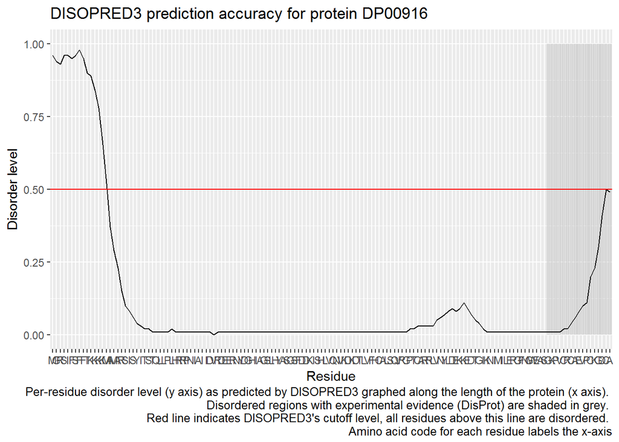

```r
ggplot() + geom_line(aes(x=factor(DP00916$Number), y=DP00916$Exp_Bin)) +
           geom_col(aes(x=DP00916$Number, y=DP00916$Exp_Bin), fill="grey", alpha=0.5) +
           geom_line(aes(x=DP00916$Number, y=DP00916$Dis_Score)) +
           geom_hline(yintercept=.5, color="red") +
           labs(x="Residue",y="Disorder level", title = "DISOPRED3 prediction accuracy for protein DP00916", caption="Per-residue disorder level (y axis) as predicted by DISOPRED3 graphed along the length of the protein (x axis). \nDisordered regions with experimental evidence (DisProt) are shaded in grey. \nRed line indicates DISOPRED3's cutoff level, all residues above this line are disordered. \nAmino acid code for each residue labels the x-axis") + scale_x_discrete(labels=DP00916$AA)
```

## DP00469

```
## geom_path: Each group consists of only one observation. Do you need to adjust the group aesthetic?
```

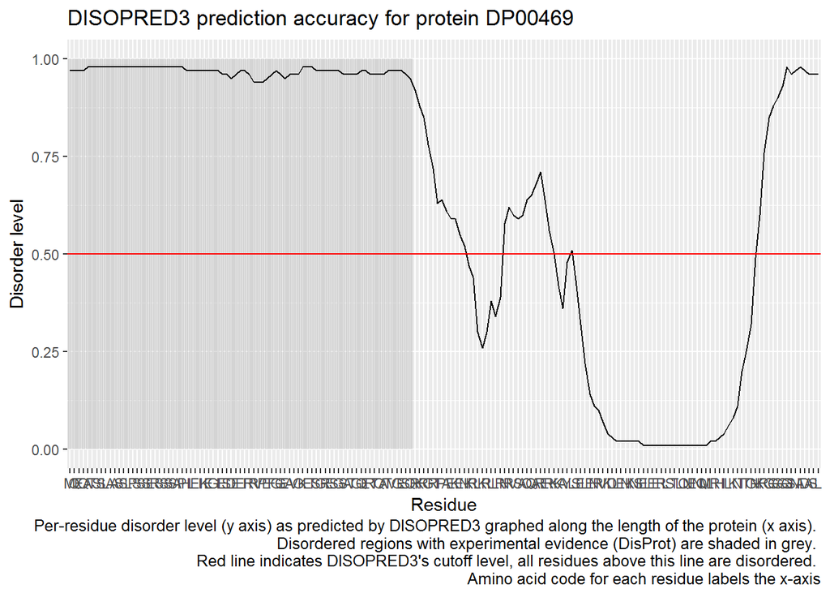

```r
ggplot() + geom_line(aes(x=factor(DP00469$Number), y=DP00469$Exp_Bin)) +
           geom_col(aes(x=DP00469$Number, y=DP00469$Exp_Bin), fill="grey", alpha=0.5) +
           geom_line(aes(x=DP00469$Number, y=DP00469$Dis_Score)) +
           geom_hline(yintercept=.5, color="red") +
           labs(x="Residue",y="Disorder level", title = "DISOPRED3 prediction accuracy for protein DP00469", caption="Per-residue disorder level (y axis) as predicted by DISOPRED3 graphed along the length of the protein (x axis). \nDisordered regions with experimental evidence (DisProt) are shaded in grey. \nRed line indicates DISOPRED3's cutoff level, all residues above this line are disordered. \nAmino acid code for each residue labels the x-axis") + scale_x_discrete(labels=DP00469$AA)
```

## Conclusions

DISOPRED3 appears to have scored well as far as predictive power goes, especially for totally disordered proteins, but it may not perform accurately for very short disordered proteins. Despite a lack of homologs being a listed caveat in reviews, it incorrectly predicted the disorder of DP00534 despite its level of conservation, meaning that the protein either is an outlier or that DISOPRED3 has a sharp decrease in predictive power for proteins shorter than approximately 130 amino acids.